# Predicting Credit Card Defaults:

### A Dataset Analysis and Comparison with Research Findings

```python
# Libraries
import pandas as pd
from sklearn.model_selection import RandomizedSearchCV, cross_validate, train_test_split
from sklearn.metrics import make_scorer, f1_score

import altair as alt
from sklearn.pipeline import Pipeline, make_pipeline
from sklearn.impute import SimpleImputer
from sklearn.preprocessing import OneHotEncoder, OrdinalEncoder, StandardScaler
from sklearn.compose import ColumnTransformer, make_column_transformer
from sklearn.dummy import DummyClassifier
from sklearn.tree import DecisionTreeRegressor, DecisionTreeClassifier
from sklearn.ensemble import RandomForestClassifier
from sklearn.neighbors import KNeighborsClassifier
from sklearn.svm import SVC
from sklearn.linear_model import LogisticRegression
from scipy.stats import loguniform
from sklearn.linear_model import RidgeClassifier
%matplotlib inline
# alt.data_transformers.enable('data_server')
alt.renderers.enable('mimetype')
```

```
RendererRegistry.enable('mimetype')
```

### Introdution

For this problem, we used [Default of Credit Card Clients Dataset](https://www.kaggle.com/uciml/default-of-credit-card-clients-dataset). In this data set, there are 30,000 examples and 24 features, and the goal is to estimate whether a person will default (fail to pay) their credit card bills; this column is labeled "default.payment.next.month" in the data. The rest of the columns can be used as features. We may take some ideas and compare our results with [the associated research paper](https://www.sciencedirect.com/science/article/pii/S0957417407006719), which is available through [the UBC library](https://www.library.ubc.ca/).

The problem at hand involves binary classification, specifically predicting whether a credit card client will default or not. The dataset in question is moderately sized, while the number of features is relatively small, making it a problem with a small dimensionality. Although all features are numerically encoded, certain ones, such as sex and marriage, appear to possess categorical characteristics.

There are 25 variables/columns in this dataset. The target variable is "default.payment.next.month" which is a binary variable with value 1 for yes (default) and 0 for no (not-default). Other variables that potentially can be considered as features are as follows:

- **ID:** a unique identification code for each customer. As each row is exclusively for one customer and the data is tidy, this varaible does not need to be considered as a feature. We can simply drop it.
- **LIMIT_BAL:** a numeric variable which shows the credit amount given to the individual or family.
- **SEX:** a binary (1 as male and 2 as female) variable.
- **EDUCATION:** an ordinal variable (1 for graduate school, 2 for university, 3 for high school, 4 for others (apparently lower education than 1 ,2, and 3), and 5 and 6 are unknown). We need to deal with the 5 and 6. Moreover, there are 14 examples with the EDUCATION value of zero, which is not defined in the dataset description. According to the response of professor "Cheng Yeh", the source delegate, to a question in this regard, I am going to consider 0,4,5, and 6 as "others". For more info see here, the discussion under the dataset at Kaggle.
- **MARRIAGE:** a categorical variable; 1 for married, 2 for single, and 3 for other. There are 54 examples with the MARRIAGE value of zero, which is not defined in the dataset description. Following professor "Cheng Yeh", I consider all zeros as "others". For more info see here.
- **AGE:** an integer variable with the range of 21 to 79. I would consider this variable as a numeric feature.
- **PAY_i:** PAY_0, PAY_2, PAY_3, PAY_4, PAY_5, PAY_6: all are ordinal features with same regular values

Value -2 is not described in the data description. Following professor "Cheng Yeh", I consider all -2 values as "no cunsumption". For more info see here.

- **BILL_AMTi:** BILL_AMT1, BILL_AMT2, BILL_AMT3, BILL_AMT4, BILL_AMT5, BILL_AMT6: Numeric feature, bill statement amount
- **PAY_AMT1:** PAY_AMT1, PAY_AMT2,PAY_AMT3,PAY_AMT4,PAY_AMT5,PAY_AMT6: Numeric feature, previous payment amount

## Reading dataset

```python
# readin the data
df = pd.read_csv("data/UCI_Credit_Card.csv")
df.head()
```

|  | ID | LIMIT_BAL | SEX | EDUCATION | MARRIAGE | AGE | PAY_0 | PAY_2 | PAY_3 | PAY_4 | ... | BILL_AMT4 | BILL_AMT5 | BILL_AMT6 | PAY_AMT1 | PAY_AMT2 | PAY_AMT3 | PAY_AMT4 | PAY_AMT5 | PAY_AMT6 | default.payment.next.month |
| --- | --- | --- | --- | --- | --- | --- | --- | --- | --- | --- | --- | --- | --- | --- | --- | --- | --- | --- | --- | --- | --- |
| 0 | 1 | 20000.0 | 2 | 2 | 1 | 24 | 2 | 2 | -1 | -1 | ... | 0.0 | 0.0 | 0.0 | 0.0 | 689.0 | 0.0 | 0.0 | 0.0 | 0.0 | 1 |
| 1 | 2 | 120000.0 | 2 | 2 | 2 | 26 | -1 | 2 | 0 | 0 | ... | 3272.0 | 3455.0 | 3261.0 | 0.0 | 1000.0 | 1000.0 | 1000.0 | 0.0 | 2000.0 | 1 |
| 2 | 3 | 90000.0 | 2 | 2 | 2 | 34 | 0 | 0 | 0 | 0 | ... | 14331.0 | 14948.0 | 15549.0 | 1518.0 | 1500.0 | 1000.0 | 1000.0 | 1000.0 | 5000.0 | 0 |
| 3 | 4 | 50000.0 | 2 | 2 | 1 | 37 | 0 | 0 | 0 | 0 | ... | 28314.0 | 28959.0 | 29547.0 | 2000.0 | 2019.0 | 1200.0 | 1100.0 | 1069.0 | 1000.0 | 0 |
| 4 | 5 | 50000.0 | 1 | 2 | 1 | 57 | -1 | 0 | -1 | 0 | ... | 20940.0 | 19146.0 | 19131.0 | 2000.0 | 36681.0 | 10000.0 | 9000.0 | 689.0 | 679.0 | 0 |

5 rows × 25 columns

```python
# general info
df.info()
```

```
<class 'pandas.core.frame.DataFrame'>
RangeIndex: 30000 entries, 0 to 29999
Data columns (total 25 columns):
 #   Column                      Non-Null Count  Dtype
---  ------                      --------------  -----
 0   ID                          30000 non-null  int64
 1   LIMIT_BAL                   30000 non-null  float64
 2   SEX                         30000 non-null  int64
 3   EDUCATION                   30000 non-null  int64
 4   MARRIAGE                    30000 non-null  int64
 5   AGE                         30000 non-null  int64
 6   PAY_0                       30000 non-null  int64
 7   PAY_2                       30000 non-null  int64
 8   PAY_3                       30000 non-null  int64
 9   PAY_4                       30000 non-null  int64
```

[output cut: 17 more lines]

```python
df.describe()
```

|  | ID | LIMIT_BAL | SEX | EDUCATION | MARRIAGE | AGE | PAY_0 | PAY_2 | PAY_3 | PAY_4 | ... | BILL_AMT4 | BILL_AMT5 | BILL_AMT6 | PAY_AMT1 | PAY_AMT2 | PAY_AMT3 | PAY_AMT4 | PAY_AMT5 | PAY_AMT6 | default.payment.next.month |
| --- | --- | --- | --- | --- | --- | --- | --- | --- | --- | --- | --- | --- | --- | --- | --- | --- | --- | --- | --- | --- | --- |
| count | 30000.000000 | 30000.000000 | 30000.000000 | 30000.000000 | 30000.000000 | 30000.000000 | 30000.000000 | 30000.000000 | 30000.000000 | 30000.000000 | ... | 30000.000000 | 30000.000000 | 30000.000000 | 30000.000000 | 3.000000e+04 | 30000.00000 | 30000.000000 | 30000.000000 | 30000.000000 | 30000.000000 |
| mean | 15000.500000 | 167484.322667 | 1.603733 | 1.853133 | 1.551867 | 35.485500 | -0.016700 | -0.133767 | -0.166200 | -0.220667 | ... | 43262.948967 | 40311.400967 | 38871.760400 | 5663.580500 | 5.921163e+03 | 5225.68150 | 4826.076867 | 4799.387633 | 5215.502567 | 0.221200 |
| std | 8660.398374 | 129747.661567 | 0.489129 | 0.790349 | 0.521970 | 9.217904 | 1.123802 | 1.197186 | 1.196868 | 1.169139 | ... | 64332.856134 | 60797.155770 | 59554.107537 | 16563.280354 | 2.304087e+04 | 17606.96147 | 15666.159744 | 15278.305679 | 17777.465775 | 0.415062 |
| min | 1.000000 | 10000.000000 | 1.000000 | 0.000000 | 0.000000 | 21.000000 | -2.000000 | -2.000000 | -2.000000 | -2.000000 | ... | -170000.000000 | -81334.000000 | -339603.000000 | 0.000000 | 0.000000e+00 | 0.00000 | 0.000000 | 0.000000 | 0.000000 | 0.000000 |
| 25% | 7500.750000 | 50000.000000 | 1.000000 | 1.000000 | 1.000000 | 28.000000 | -1.000000 | -1.000000 | -1.000000 | -1.000000 | ... | 2326.750000 | 1763.000000 | 1256.000000 | 1000.000000 | 8.330000e+02 | 390.00000 | 296.000000 | 252.500000 | 117.750000 | 0.000000 |
| 50% | 15000.500000 | 140000.000000 | 2.000000 | 2.000000 | 2.000000 | 34.000000 | 0.000000 | 0.000000 | 0.000000 | 0.000000 | ... | 19052.000000 | 18104.500000 | 17071.000000 | 2100.000000 | 2.009000e+03 | 1800.00000 | 1500.000000 | 1500.000000 | 1500.000000 | 0.000000 |
| 75% | 22500.250000 | 240000.000000 | 2.000000 | 2.000000 | 2.000000 | 41.000000 | 0.000000 | 0.000000 | 0.000000 | 0.000000 | ... | 54506.000000 | 50190.500000 | 49198.250000 | 5006.000000 | 5.000000e+03 | 4505.00000 | 4013.250000 | 4031.500000 | 4000.000000 | 0.000000 |
| max | 30000.000000 | 1000000.000000 | 2.000000 | 6.000000 | 3.000000 | 79.000000 | 8.000000 | 8.000000 | 8.000000 | 8.000000 | ... | 891586.000000 | 927171.000000 | 961664.000000 | 873552.000000 | 1.684259e+06 | 896040.00000 | 621000.000000 | 426529.000000 | 528666.000000 | 1.000000 |

8 rows × 25 columns

## Data Cleaning

There are some non-defined values in Eduacation (and some other columns).

```python
df['EDUCATION'].unique()
```

```
array([2, 1, 3, 5, 4, 6, 0], dtype=int64)
```

```python
df[df['EDUCATION']==0]['EDUCATION'].count()
```

```
14
```

Let's rename the target column "default.payment.next.month" to "target"

```python
df.rename(columns = {'default.payment.next.month':'target'}, inplace= True)
```

According to professor "Cheng Yeh" to a query in this regard, all EDUCATION values 0, 4, 5, and 6 should be considered as "others". For more info see here. So, I change all these value to "4" to be consistent.

```python
df['EDUCATION'] = df['EDUCATION'].replace(0, int(4))
df['EDUCATION'] = df['EDUCATION'].replace(5, int(4))
df['EDUCATION'] = df['EDUCATION'].replace(6, int(4))
```

```python
df['SEX'].unique()
```

```
array([2, 1], dtype=int64)
```

Let's convert the type of some variables to suitable ones so we can gat more appropriate plots.

```python
# df['target']= df['target'].astype(bool)
df['SEX'] = df['SEX'].replace(1, int(0))
df['SEX'] = df['SEX'].replace(2, int(1))
df['SEX']= df['SEX'].astype(object)
df['EDUCATION']= df['EDUCATION'].astype(object)
df['MARRIAGE']= df['MARRIAGE'].astype(object)
df['PAY_0']= df['PAY_0'].astype(object)
df['PAY_2']= df['PAY_2'].astype(object)
df['PAY_3']= df['PAY_3'].astype(object)
df['PAY_4']= df['PAY_4'].astype(object)
df['PAY_5']= df['PAY_5'].astype(object)
df['PAY_6']= df['PAY_6'].astype(object)
```

## Data Splitting

```python
train_df, test_df = train_test_split(df, test_size=0.3, random_state=123)
train_df.shape
```

```
(21000, 25)
```

## EDA

```python
train_df.info()
train_df.describe()
```

```
<class 'pandas.core.frame.DataFrame'>
Int64Index: 21000 entries, 16395 to 19966
Data columns (total 25 columns):
 #   Column     Non-Null Count  Dtype
---  ------     --------------  -----
 0   ID         21000 non-null  int64
 1   LIMIT_BAL  21000 non-null  float64
 2   SEX        21000 non-null  object
 3   EDUCATION  21000 non-null  object
 4   MARRIAGE   21000 non-null  object
 5   AGE        21000 non-null  int64
 6   PAY_0      21000 non-null  object
 7   PAY_2      21000 non-null  object
 8   PAY_3      21000 non-null  object
 9   PAY_4      21000 non-null  object
```

[output cut: 17 more lines]

|  | ID | LIMIT_BAL | AGE | BILL_AMT1 | BILL_AMT2 | BILL_AMT3 | BILL_AMT4 | BILL_AMT5 | BILL_AMT6 | PAY_AMT1 | PAY_AMT2 | PAY_AMT3 | PAY_AMT4 | PAY_AMT5 | PAY_AMT6 | target |
| --- | --- | --- | --- | --- | --- | --- | --- | --- | --- | --- | --- | --- | --- | --- | --- | --- |
| count | 21000.000000 | 21000.000000 | 21000.000000 | 21000.000000 | 21000.000000 | 21000.000000 | 21000.000000 | 21000.000000 | 21000.000000 | 21000.000000 | 2.100000e+04 | 21000.000000 | 21000.000000 | 21000.000000 | 21000.000000 | 21000.000000 |
| mean | 14962.348238 | 167880.651429 | 35.500810 | 51107.566762 | 49126.824810 | 47010.414095 | 43486.610905 | 40428.518333 | 38767.202667 | 5673.585143 | 5.895027e+03 | 5311.432286 | 4774.021381 | 4751.850095 | 5237.762190 | 0.223238 |
| std | 8650.734050 | 130202.682167 | 9.212644 | 73444.143025 | 71400.032096 | 69035.759516 | 64843.303993 | 61187.200817 | 59587.689549 | 17033.241454 | 2.180143e+04 | 18377.997079 | 15434.136142 | 15228.193125 | 18116.846563 | 0.416427 |
| min | 1.000000 | 10000.000000 | 21.000000 | -15308.000000 | -67526.000000 | -157264.000000 | -50616.000000 | -61372.000000 | -339603.000000 | 0.000000 | 0.000000e+00 | 0.000000 | 0.000000 | 0.000000 | 0.000000 | 0.000000 |
| 25% | 7498.750000 | 50000.000000 | 28.000000 | 3649.250000 | 2925.750000 | 2663.750000 | 2293.750000 | 1739.500000 | 1215.750000 | 1000.000000 | 8.200000e+02 | 390.000000 | 266.000000 | 234.000000 | 110.750000 | 0.000000 |
| 50% | 14960.500000 | 140000.000000 | 34.000000 | 22284.000000 | 21002.500000 | 20088.500000 | 19102.500000 | 18083.000000 | 16854.500000 | 2100.000000 | 2.007000e+03 | 1809.500000 | 1500.000000 | 1500.000000 | 1500.000000 | 0.000000 |
| 75% | 22458.250000 | 240000.000000 | 41.000000 | 66979.750000 | 63795.250000 | 59895.000000 | 54763.250000 | 50491.000000 | 49253.750000 | 5007.250000 | 5.000000e+03 | 4628.500000 | 4021.250000 | 4016.000000 | 4000.000000 | 0.000000 |
| max | 30000.000000 | 1000000.000000 | 79.000000 | 964511.000000 | 983931.000000 | 855086.000000 | 891586.000000 | 927171.000000 | 961664.000000 | 873552.000000 | 1.227082e+06 | 896040.000000 | 621000.000000 | 426529.000000 | 528666.000000 | 1.000000 |

```python
train_df["target"].value_counts(normalize=True)
```

```
0    0.776762
1    0.223238
Name: target, dtype: float64
```

In our dataset, there exists a class imbalance issue, where both classes hold significance. To address this, I will choose the macro-average F1 score as the evaluation metric for our model.

```python
custom_scorer = make_scorer(f1_score, average="macro")
scoring_metric = custom_scorer
train_df.max()
```

```
ID               30000
LIMIT_BAL    1000000.0
SEX                  1
EDUCATION            4
MARRIAGE             3
AGE                 79
PAY_0                8
PAY_2                8
PAY_3                8
PAY_4                8
PAY_5                8
PAY_6                8
BILL_AMT1     964511.0
BILL_AMT2     983931.0
BILL_AMT3     855086.0
BILL_AMT4     891586.0
BILL_AMT5     927171.0
BILL_AMT6     961664.0
PAY_AMT1      873552.0
PAY_AMT2     1227082.0
PAY_AMT3      896040.0
PAY_AMT4      621000.0
PAY_AMT5      426529.0
PAY_AMT6      528666.0
target               1
dtype: object
```

```python
X_train, y_train = (
    train_df.drop(columns=["target"]),
    train_df["target"],
)
X_test, y_test = (
    test_df.drop(columns=["target"]),
    test_df["target"],
)
```

Seems like all `PAY_\d*` features and `BILL_AMT\d*` features are highly correlated.

```python
alt.data_transformers.disable_max_rows()

alt.Chart(train_df).mark_bar().encode(
     alt.X(alt.repeat(), type='quantitative', bin=alt.Bin(maxbins=15)),
     y='count()',
     color='target'
).properties(
    width=300,
    height=200
).repeat(
    ['AGE','LIMIT_BAL', 'BILL_AMT1', 'BILL_AMT2', 'BILL_AMT3', 'BILL_AMT4', 'BILL_AMT5' , 'BILL_AMT6'],
    columns = 2
)
```

[output not shown]

```python
alt.data_transformers.disable_max_rows()

train_df_cols = train_df.columns.tolist()
eda_plot = {}
for column in train_df:
        eda_plot[column] = (alt.Chart(train_df)
            .transform_density(
                column,
                groupby=['target'],
                as_=[column, 'density'])
            .mark_area(opacity=0.4).encode(
                x=column,
                y='density:Q',
                color=alt.Color('target', scale=alt.Scale(scheme='set1'))))
```

```python
eda_plot['EDUCATION']
```

[output not shown]

```python
eda_plot['LIMIT_BAL']
```

[output not shown]

```python
eda_plot['MARRIAGE']
```

[output not shown]

```python
(eda_plot['PAY_0'] | eda_plot['PAY_2'] | eda_plot['PAY_3']) & (eda_plot['PAY_4'] | eda_plot['PAY_5']| eda_plot['PAY_6'])
```

[output not shown]

```python
(eda_plot['BILL_AMT1'] | eda_plot['BILL_AMT2'] | eda_plot['BILL_AMT3']) & (eda_plot['BILL_AMT4'] | eda_plot['BILL_AMT5']| eda_plot['BILL_AMT6'])
```

[output not shown]

```python
# Correlation matrix
corr_plot = train_df.corr('spearman').style.background_gradient()
corr_plot
```

|  | ID | LIMIT_BAL | AGE | BILL_AMT1 | BILL_AMT2 | BILL_AMT3 | BILL_AMT4 | BILL_AMT5 | BILL_AMT6 | PAY_AMT1 | PAY_AMT2 | PAY_AMT3 | PAY_AMT4 | PAY_AMT5 | PAY_AMT6 | target |
| --- | --- | --- | --- | --- | --- | --- | --- | --- | --- | --- | --- | --- | --- | --- | --- | --- |
| ID | 1.000000 | 0.031870 | 0.027827 | 0.011770 | 0.012245 | 0.019705 | 0.034273 | 0.017021 | 0.021023 | 0.014178 | 0.057371 | 0.093794 | 0.020229 | 0.012388 | 0.043129 | -0.017860 |
| LIMIT_BAL | 0.031870 | 1.000000 | 0.187551 | 0.052353 | 0.044550 | 0.061585 | 0.075304 | 0.080532 | 0.089491 | 0.269081 | 0.280864 | 0.284313 | 0.282712 | 0.295397 | 0.317743 | -0.163434 |
| AGE | 0.027827 | 0.187551 | 1.000000 | 0.009236 | 0.008098 | 0.009623 | 0.004202 | 0.008244 | 0.008474 | 0.035213 | 0.045929 | 0.034749 | 0.045447 | 0.041562 | 0.043813 | 0.001015 |
| BILL_AMT1 | 0.011770 | 0.052353 | 0.009236 | 1.000000 | 0.911925 | 0.858215 | 0.806596 | 0.765675 | 0.730706 | 0.502950 | 0.473786 | 0.443784 | 0.438539 | 0.424758 | 0.408598 | -0.026482 |
| BILL_AMT2 | 0.012245 | 0.044550 | 0.008098 | 0.911925 | 1.000000 | 0.908939 | 0.848691 | 0.801162 | 0.762253 | 0.635515 | 0.499097 | 0.471044 | 0.458127 | 0.448360 | 0.426155 | -0.015484 |
| BILL_AMT3 | 0.019705 | 0.061585 | 0.009623 | 0.858215 | 0.908939 | 1.000000 | 0.904012 | 0.848687 | 0.801807 | 0.552242 | 0.639697 | 0.496114 | 0.490258 | 0.478470 | 0.458361 | -0.012799 |
| BILL_AMT4 | 0.034273 | 0.075304 | 0.004202 | 0.806596 | 0.848691 | 0.904012 | 1.000000 | 0.903270 | 0.846959 | 0.516231 | 0.557846 | 0.639006 | 0.510618 | 0.507286 | 0.479767 | -0.010306 |
| BILL_AMT5 | 0.017021 | 0.080532 | 0.008244 | 0.765675 | 0.801162 | 0.848687 | 0.903270 | 1.000000 | 0.901175 | 0.483915 | 0.519284 | 0.552499 | 0.650117 | 0.527912 | 0.507230 | -0.005362 |
| BILL_AMT6 | 0.021023 | 0.089491 | 0.008474 | 0.730706 | 0.762253 | 0.801807 | 0.846959 | 0.901175 | 1.000000 | 0.455541 | 0.486953 | 0.521666 | 0.573916 | 0.669168 | 0.530022 | 0.000419 |
| PAY_AMT1 | 0.014178 | 0.269081 | 0.035213 | 0.502950 | 0.635515 | 0.552242 | 0.516231 | 0.483915 | 0.455541 | 1.000000 | 0.515398 | 0.524049 | 0.482587 | 0.472121 | 0.453552 | -0.160152 |
| PAY_AMT2 | 0.057371 | 0.280864 | 0.045929 | 0.473786 | 0.499097 | 0.639697 | 0.557846 | 0.519284 | 0.486953 | 0.515398 | 1.000000 | 0.521633 | 0.523679 | 0.497974 | 0.497296 | -0.155559 |
| PAY_AMT3 | 0.093794 | 0.284313 | 0.034749 | 0.443784 | 0.471044 | 0.496114 | 0.639006 | 0.552499 | 0.521666 | 0.524049 | 0.521633 | 1.000000 | 0.516219 | 0.538048 | 0.502699 | -0.143714 |
| PAY_AMT4 | 0.020229 | 0.282712 | 0.045447 | 0.438539 | 0.458127 | 0.490258 | 0.510618 | 0.650117 | 0.573916 | 0.482587 | 0.523679 | 0.516219 | 1.000000 | 0.540475 | 0.547271 | -0.127439 |
| PAY_AMT5 | 0.012388 | 0.295397 | 0.041562 | 0.424758 | 0.448360 | 0.478470 | 0.507286 | 0.527912 | 0.669168 | 0.472121 | 0.497974 | 0.538048 | 0.540475 | 1.000000 | 0.554174 | -0.121818 |
| PAY_AMT6 | 0.043129 | 0.317743 | 0.043813 | 0.408598 | 0.426155 | 0.458361 | 0.479767 | 0.507230 | 0.530022 | 0.453552 | 0.497296 | 0.502699 | 0.547271 | 0.554174 | 1.000000 | -0.117977 |
| target | -0.017860 | -0.163434 | 0.001015 | -0.026482 | -0.015484 | -0.012799 | -0.010306 | -0.005362 | 0.000419 | -0.160152 | -0.155559 | -0.143714 | -0.127439 | -0.121818 | -0.117977 | 1.000000 |

Initial observations:

- The number of features is limited.
- Class imbalance is present and requires addressing. The chosen evaluation metric is macro-average F1 score, which gives equal weight to both classes.
- The feature ranges vary significantly, necessitating standardization.
- Collinearity is observed among some features.
- Several outliers are present in the data.
- The data appears to be messy and inconsistent with the provided description.
  - There is uncertainty regarding education levels 5 and 6.
  - The meaning of values -2 and 0 for PAY_* features is unclear.
- Notable outliers are observed in features such as 'EDUCATION', 'MARRIAGE', and 'PAY_\d*'.

## Feature engineering

```python
from sklearn.preprocessing import PolynomialFeatures
poly_feats = PolynomialFeatures(degree=2, interaction_only = True, include_bias = False )
X_train_pr  = X_train
X_train_pr = X_train_pr.drop(columns = "ID")
X_enc = poly_feats.fit_transform(X_train_pr)
df = pd.DataFrame(X_enc, columns=poly_feats.get_feature_names_out()).describe()
df
```

|  | LIMIT_BAL | SEX | EDUCATION | MARRIAGE | AGE | PAY_0 | PAY_2 | PAY_3 | PAY_4 | PAY_5 | ... | PAY_AMT2 PAY_AMT3 | PAY_AMT2 PAY_AMT4 | PAY_AMT2 PAY_AMT5 | PAY_AMT2 PAY_AMT6 | PAY_AMT3 PAY_AMT4 | PAY_AMT3 PAY_AMT5 | PAY_AMT3 PAY_AMT6 | PAY_AMT4 PAY_AMT5 | PAY_AMT4 PAY_AMT6 | PAY_AMT5 PAY_AMT6 |
| --- | --- | --- | --- | --- | --- | --- | --- | --- | --- | --- | --- | --- | --- | --- | --- | --- | --- | --- | --- | --- | --- |
| count | 21000.000000 | 21000.000000 | 21000.000000 | 21000.000000 | 21000.000000 | 21000.000000 | 21000.000000 | 21000.000000 | 21000.000000 | 21000.000000 | ... | 2.100000e+04 | 2.100000e+04 | 2.100000e+04 | 2.100000e+04 | 2.100000e+04 | 2.100000e+04 | 2.100000e+04 | 2.100000e+04 | 2.100000e+04 | 2.100000e+04 |
| mean | 167880.651429 | 0.600762 | 1.840714 | 1.554000 | 35.500810 | -0.015429 | -0.137095 | -0.171619 | -0.225238 | -0.264429 | ... | 1.386941e+08 | 9.974850e+07 | 7.259665e+07 | 9.940517e+07 | 8.907482e+07 | 6.500406e+07 | 7.666119e+07 | 5.248053e+07 | 6.671355e+07 | 6.383740e+07 |
| std | 130202.682167 | 0.489753 | 0.745167 | 0.521675 | 9.212644 | 1.120465 | 1.194506 | 1.196123 | 1.168556 | 1.137205 | ... | 7.619618e+09 | 5.237682e+09 | 1.532914e+09 | 1.957650e+09 | 3.850991e+09 | 7.938165e+08 | 1.239316e+09 | 4.310717e+08 | 9.982386e+08 | 6.493147e+08 |
| min | 10000.000000 | 0.000000 | 1.000000 | 0.000000 | 21.000000 | -2.000000 | -2.000000 | -2.000000 | -2.000000 | -2.000000 | ... | 0.000000e+00 | 0.000000e+00 | 0.000000e+00 | 0.000000e+00 | 0.000000e+00 | 0.000000e+00 | 0.000000e+00 | 0.000000e+00 | 0.000000e+00 | 0.000000e+00 |
| 25% | 50000.000000 | 0.000000 | 1.000000 | 1.000000 | 28.000000 | -1.000000 | -1.000000 | -1.000000 | -1.000000 | -1.000000 | ... | 0.000000e+00 | 0.000000e+00 | 0.000000e+00 | 0.000000e+00 | 0.000000e+00 | 0.000000e+00 | 0.000000e+00 | 0.000000e+00 | 0.000000e+00 | 0.000000e+00 |
| 50% | 140000.000000 | 1.000000 | 2.000000 | 2.000000 | 34.000000 | 0.000000 | 0.000000 | 0.000000 | 0.000000 | 0.000000 | ... | 2.890000e+06 | 2.324252e+06 | 2.316370e+06 | 2.236850e+06 | 1.736800e+06 | 1.950981e+06 | 1.800000e+06 | 1.403960e+06 | 1.500000e+06 | 1.396836e+06 |
| 75% | 240000.000000 | 1.000000 | 2.000000 | 2.000000 | 41.000000 | 0.000000 | 0.000000 | 0.000000 | 0.000000 | 0.000000 | ... | 1.800000e+07 | 1.600000e+07 | 1.600000e+07 | 1.575000e+07 | 1.405280e+07 | 1.462222e+07 | 1.400000e+07 | 1.290530e+07 | 1.297522e+07 | 1.280547e+07 |
| max | 1000000.000000 | 1.000000 | 4.000000 | 3.000000 | 79.000000 | 8.000000 | 8.000000 | 8.000000 | 8.000000 | 8.000000 | ... | 1.080606e+12 | 7.548075e+11 | 1.676152e+11 | 1.762433e+11 | 5.520957e+11 | 6.295740e+10 | 1.289112e+11 | 2.527152e+10 | 9.004500e+10 | 6.224987e+10 |

8 rows × 276 columns

we can use polynomial features in feature engineering but in this problem we will approach without the feature engineering.

```python
# Let's identify numeric and categorical features
drop_features = ["ID"]
numeric_features = [
    "LIMIT_BAL",
    "PAY_0",
    "PAY_2",
    "PAY_3",
    "PAY_4",
    "PAY_5",
    "PAY_6",
    "BILL_AMT1",
    "BILL_AMT2",
    "BILL_AMT3",
    "BILL_AMT4",
    "BILL_AMT5",
    "BILL_AMT6",
    "PAY_AMT1",
    "PAY_AMT2",
    "PAY_AMT3",
    "PAY_AMT4",
    "PAY_AMT5",
    "PAY_AMT6",
    "AGE",
]
binary_features = ["SEX"]
categorical_features = ["EDUCATION", "MARRIAGE"]
target = "default.payment.next.month"
```

```python
from sklearn.compose import make_column_transformer
from sklearn.preprocessing import StandardScaler, OneHotEncoder

preprocessor = make_column_transformer(
    ("drop", drop_features),
    (StandardScaler(), numeric_features),
    (OneHotEncoder(drop="if_binary"), binary_features),
    (OneHotEncoder(handle_unknown="ignore"), categorical_features),
)
```

```python
def mean_std_cross_val_scores(model, X_train, y_train, **kwargs):
    """
    Returns mean and std of cross validation

    Parameters
    ----------
    model :
        scikit-learn model
    X_train : numpy array or pandas DataFrame
        X in the training data
    y_train :
        y in the training data

    Returns
    ----------
        pandas Series with mean scores from cross_validation
    """

    scores = cross_validate(model, X_train, y_train, **kwargs)

    mean_scores = pd.DataFrame(scores).mean()
    std_scores = pd.DataFrame(scores).std()
    out_col = []

    for i in range(len(mean_scores)):
        out_col.append((f"%0.3f (+/- %0.3f)" % (mean_scores[i], std_scores[i])))

    return pd.Series(data=out_col, index=mean_scores.index)

results = {}
```

Baseline model

```python
from sklearn.dummy import DummyClassifier
from sklearn.model_selection import cross_validate

dummy = DummyClassifier(strategy="stratified")
results["dummy"] = mean_std_cross_val_scores(
    dummy, X_train, y_train, return_train_score=True, scoring=scoring_metric
)
pd.DataFrame(results)
```

|  | dummy |
| --- | --- |
| fit_time | 0.005 (+/- 0.005) |
| score_time | 0.002 (+/- 0.004) |
| test_score | 0.499 (+/- 0.005) |
| train_score | 0.502 (+/- 0.003) |

## Linear models

```python
from sklearn.pipeline import make_pipeline
from sklearn.linear_model import LogisticRegression

pipe_lr = make_pipeline(
    preprocessor, LogisticRegression(max_iter=1000, class_weight="balanced")
)
results["logreg"] = mean_std_cross_val_scores(
    pipe_lr, X_train, y_train, return_train_score=True, scoring=scoring_metric
)
pd.DataFrame(results)
```

|  | dummy | logreg |
| --- | --- | --- |
| fit_time | 0.005 (+/- 0.005) | 0.438 (+/- 0.086) |
| score_time | 0.002 (+/- 0.004) | 0.031 (+/- 0.006) |
| test_score | 0.499 (+/- 0.005) | 0.625 (+/- 0.006) |
| train_score | 0.502 (+/- 0.003) | 0.627 (+/- 0.003) |

```python
from scipy.stats import lognorm, loguniform, randint
from sklearn.model_selection import RandomizedSearchCV

param_grid = {"logisticregression__C": loguniform(1e-3, 1e3)}

random_search = RandomizedSearchCV(
    pipe_lr,
    param_grid,
    n_iter=50,
    verbose=1,
    scoring=scoring_metric,
    random_state=123,
    return_train_score=True,
)

random_search.fit(X_train, y_train);
```

```
Fitting 5 folds for each of 50 candidates, totalling 250 fits
```

```python
print("Best hyperparameter values: ", random_search.best_params_)
print("Best score: %0.3f" % (random_search.best_score_))

pd.DataFrame(random_search.cv_results_)[
    [
        "mean_train_score",
        "mean_test_score",
        "param_logisticregression__C",
        "mean_fit_time",
        "rank_test_score",
        "std_test_score",
    ]
].set_index("rank_test_score").sort_index()[:10]
```

```
Best hyperparameter values:  {'logisticregression__C': 0.011290431413903906}
Best score: 0.629
```

| rank_test_score | mean_train_score | mean_test_score | param_logisticregression__C | mean_fit_time | std_test_score |
| --- | --- | --- | --- | --- | --- |
| 1 | 0.630241 | 0.629204 | 0.01129 | 0.211592 | 0.005337 |
| 2 | 0.630248 | 0.629055 | 0.00494 | 0.183178 | 0.005957 |
| 3 | 0.630127 | 0.628931 | 0.012444 | 0.187974 | 0.005926 |
| 4 | 0.630183 | 0.628283 | 0.00357 | 0.176570 | 0.005044 |
| 5 | 0.629997 | 0.627959 | 0.022967 | 0.259679 | 0.005810 |
| 6 | 0.629976 | 0.627919 | 0.02342 | 0.226556 | 0.005837 |
| 7 | 0.629423 | 0.627908 | 0.002281 | 0.167940 | 0.005087 |
| 8 | 0.629597 | 0.627387 | 0.031822 | 0.245622 | 0.005378 |
| 9 | 0.628989 | 0.626985 | 0.0521 | 0.302313 | 0.005228 |
| 10 | 0.628934 | 0.626945 | 0.057847 | 0.248444 | 0.005150 |

```python
best_logreg = random_search.best_estimator_
results["logreg (tuned)"] = mean_std_cross_val_scores(
    best_logreg, X_train, y_train, return_train_score=True, scoring=scoring_metric
)

pd.DataFrame(results).T
```

|  | fit_time | score_time | test_score | train_score |
| --- | --- | --- | --- | --- |
| dummy | 0.005 (+/- 0.005) | 0.002 (+/- 0.004) | 0.499 (+/- 0.005) | 0.502 (+/- 0.003) |
| logreg | 0.438 (+/- 0.086) | 0.031 (+/- 0.006) | 0.625 (+/- 0.006) | 0.627 (+/- 0.003) |
| logreg (tuned) | 0.250 (+/- 0.032) | 0.032 (+/- 0.005) | 0.629 (+/- 0.006) | 0.630 (+/- 0.003) |

- Logistic regression scores are better than the dummy classifier scores.
- Optimizing the regularization hyperparameter of logistic regression improved the validation scores slightly (from 0.625 to 0.629) but not by much.
- In both cases it seems like we are underfitting; there is not much gap between train and validation scores. Probably non-linear models might be a better choice here.

## Different models

```python
import numpy as np
ratio = np.bincount(y_train)[0] / np.bincount(y_train)[1]
ratio
```

```
3.4795221843003414
```

```python
from lightgbm.sklearn import LGBMClassifier
from sklearn.ensemble import RandomForestClassifier
from sklearn.svm import SVC
from xgboost import XGBClassifier

models = {
    "RBF SVM": SVC(),
    "random forest": RandomForestClassifier(class_weight="balanced", random_state=2),
    "xgboost": XGBClassifier(scale_pos_weight=ratio, random_state=2),
    "lgbm": LGBMClassifier(scale_pos_weight=ratio, random_state=2),
}

for name, model in models.items():
    pipe = make_pipeline(preprocessor, model)
    results[name] = mean_std_cross_val_scores(
        pipe, X_train, y_train, return_train_score=True, scoring=scoring_metric
    )

pd.DataFrame(results).T
```

|  | fit_time | score_time | test_score | train_score |
| --- | --- | --- | --- | --- |
| dummy | 0.005 (+/- 0.005) | 0.002 (+/- 0.004) | 0.499 (+/- 0.005) | 0.502 (+/- 0.003) |
| logreg | 0.438 (+/- 0.086) | 0.031 (+/- 0.006) | 0.625 (+/- 0.006) | 0.627 (+/- 0.003) |
| logreg (tuned) | 0.250 (+/- 0.032) | 0.032 (+/- 0.005) | 0.629 (+/- 0.006) | 0.630 (+/- 0.003) |
| RBF SVM | 38.009 (+/- 5.924) | 10.184 (+/- 3.418) | 0.675 (+/- 0.008) | 0.686 (+/- 0.002) |
| random forest | 6.900 (+/- 0.397) | 0.214 (+/- 0.040) | 0.669 (+/- 0.006) | 0.999 (+/- 0.000) |
| xgboost | 2.396 (+/- 0.563) | 0.041 (+/- 0.006) | 0.682 (+/- 0.012) | 0.866 (+/- 0.007) |
| lgbm | 0.491 (+/- 0.045) | 0.049 (+/- 0.003) | 0.690 (+/- 0.010) | 0.773 (+/- 0.003) |

```python
del models["RBF SVM"]
```

## Feature selection

```python
from sklearn.feature_selection import SelectFromModel

for name, model in models.items():
    pipe = make_pipeline(
        preprocessor,
        SelectFromModel(
            LogisticRegression(solver="liblinear", penalty="l1", max_iter=1000)
        ),
        model,
    )
    results[name + "+ feat_sel"] = mean_std_cross_val_scores(
        pipe, X_train, y_train, return_train_score=True, scoring=scoring_metric
    )
```

```python
pd.DataFrame(results).T
```

|  | fit_time | score_time | test_score | train_score |
| --- | --- | --- | --- | --- |
| dummy | 0.005 (+/- 0.005) | 0.002 (+/- 0.004) | 0.499 (+/- 0.005) | 0.502 (+/- 0.003) |
| logreg | 0.438 (+/- 0.086) | 0.031 (+/- 0.006) | 0.625 (+/- 0.006) | 0.627 (+/- 0.003) |
| logreg (tuned) | 0.250 (+/- 0.032) | 0.032 (+/- 0.005) | 0.629 (+/- 0.006) | 0.630 (+/- 0.003) |
| RBF SVM | 38.009 (+/- 5.924) | 10.184 (+/- 3.418) | 0.675 (+/- 0.008) | 0.686 (+/- 0.002) |
| random forest | 6.900 (+/- 0.397) | 0.214 (+/- 0.040) | 0.669 (+/- 0.006) | 0.999 (+/- 0.000) |
| xgboost | 2.396 (+/- 0.563) | 0.041 (+/- 0.006) | 0.682 (+/- 0.012) | 0.866 (+/- 0.007) |
| lgbm | 0.491 (+/- 0.045) | 0.049 (+/- 0.003) | 0.690 (+/- 0.010) | 0.773 (+/- 0.003) |
| random forest+ feat_sel | 9.239 (+/- 0.784) | 0.198 (+/- 0.017) | 0.673 (+/- 0.008) | 0.999 (+/- 0.000) |
| xgboost+ feat_sel | 4.337 (+/- 0.867) | 0.038 (+/- 0.002) | 0.683 (+/- 0.012) | 0.864 (+/- 0.007) |
| lgbm+ feat_sel | 3.216 (+/- 0.524) | 0.049 (+/- 0.001) | 0.692 (+/- 0.009) | 0.772 (+/- 0.002) |

```python
pipe_random_forest = make_pipeline(
    preprocessor,
    SelectFromModel(
        LogisticRegression(solver="liblinear", penalty="l1", max_iter=1000)
    ),
    models["random forest"],
)

pipe_random_forest.fit(X_train, y_train)
print(
    "Number of features selected: ",
    pipe_random_forest.named_steps["randomforestclassifier"].n_features_,
)
```

```
Number of features selected:  26
```

## Hyperparameter optimization

```python
# Random forest hyperparameter optimization
param_grid_rf = {
    "randomforestclassifier__n_estimators": randint(low=10, high=100),
    "randomforestclassifier__max_depth": randint(low=2, high=20),
}

pipe_random_forest = make_pipeline(preprocessor, models["random forest"])
```

```python
random_search_rf = RandomizedSearchCV(
    pipe_random_forest,
    param_grid_rf,
    n_iter=50,
    verbose=1,
    scoring=scoring_metric,
    random_state=123,
    return_train_score=True,
)

random_search_rf.fit(X_train, y_train)
```

```
Fitting 5 folds for each of 50 candidates, totalling 250 fits
```

[output not shown]

```python
print("Best hyperparameter values: ", random_search_rf.best_params_)
print("Best score: %0.3f" % (random_search_rf.best_score_))

pd.DataFrame(random_search_rf.cv_results_)[
    [
        "mean_train_score",
        "mean_test_score",
        "param_randomforestclassifier__n_estimators",
        "param_randomforestclassifier__max_depth",
        "mean_fit_time",
        "rank_test_score",
        "std_test_score",
    ]
].set_index("rank_test_score").sort_index()[:10]
```

```
Best hyperparameter values:  {'randomforestclassifier__max_depth': 9, 'randomforestclassifier__n_estimators': 76}
Best score: 0.705
```

| rank_test_score | mean_train_score | mean_test_score | param_randomforestclassifier__n_estimators | param_randomforestclassifier__max_depth | mean_fit_time | std_test_score |
| --- | --- | --- | --- | --- | --- | --- |
| 1 | 0.753037 | 0.705216 | 76 | 9 | 3.061300 | 0.008518 |
| 2 | 0.792472 | 0.704517 | 62 | 11 | 3.000436 | 0.010562 |
| 3 | 0.867472 | 0.703849 | 58 | 14 | 3.169375 | 0.009207 |
| 4 | 0.771308 | 0.703614 | 35 | 10 | 3.492585 | 0.008976 |
| 5 | 0.706565 | 0.703092 | 86 | 4 | 1.805443 | 0.010889 |
| 6 | 0.792655 | 0.702651 | 42 | 11 | 1.888211 | 0.009543 |
| 7 | 0.841542 | 0.702619 | 68 | 13 | 3.533755 | 0.008596 |
| 8 | 0.738597 | 0.702415 | 95 | 8 | 3.360659 | 0.007672 |
| 9 | 0.735297 | 0.702265 | 19 | 8 | 0.723056 | 0.009039 |
| 10 | 0.816931 | 0.702246 | 67 | 12 | 3.301626 | 0.007821 |

```python
best_rf_model = random_search_rf.best_estimator_
results["random forest (tuned)"] = mean_std_cross_val_scores(
    best_rf_model, X_train, y_train, return_train_score=True, scoring=scoring_metric
)
pd.DataFrame(results).T
```

|  | fit_time | score_time | test_score | train_score |
| --- | --- | --- | --- | --- |
| dummy | 0.005 (+/- 0.005) | 0.002 (+/- 0.004) | 0.499 (+/- 0.005) | 0.502 (+/- 0.003) |
| logreg | 0.438 (+/- 0.086) | 0.031 (+/- 0.006) | 0.625 (+/- 0.006) | 0.627 (+/- 0.003) |
| logreg (tuned) | 0.250 (+/- 0.032) | 0.032 (+/- 0.005) | 0.629 (+/- 0.006) | 0.630 (+/- 0.003) |
| RBF SVM | 38.009 (+/- 5.924) | 10.184 (+/- 3.418) | 0.675 (+/- 0.008) | 0.686 (+/- 0.002) |
| random forest | 6.900 (+/- 0.397) | 0.214 (+/- 0.040) | 0.669 (+/- 0.006) | 0.999 (+/- 0.000) |
| xgboost | 2.396 (+/- 0.563) | 0.041 (+/- 0.006) | 0.682 (+/- 0.012) | 0.866 (+/- 0.007) |
| lgbm | 0.491 (+/- 0.045) | 0.049 (+/- 0.003) | 0.690 (+/- 0.010) | 0.773 (+/- 0.003) |
| random forest+ feat_sel | 9.239 (+/- 0.784) | 0.198 (+/- 0.017) | 0.673 (+/- 0.008) | 0.999 (+/- 0.000) |
| xgboost+ feat_sel | 4.337 (+/- 0.867) | 0.038 (+/- 0.002) | 0.683 (+/- 0.012) | 0.864 (+/- 0.007) |
| lgbm+ feat_sel | 3.216 (+/- 0.524) | 0.049 (+/- 0.001) | 0.692 (+/- 0.009) | 0.772 (+/- 0.002) |
| random forest (tuned) | 6.302 (+/- 0.371) | 0.210 (+/- 0.032) | 0.705 (+/- 0.010) | 0.753 (+/- 0.003) |

```python
# LGBM hyperparameter optimization
param_grid_lgbm = {
    "lgbmclassifier__n_estimators": randint(10, 100),
    "lgbmclassifier__max_depth": randint(low=2, high=20),
    "lgbmclassifier__learning_rate": [0.01, 0.1],
    "lgbmclassifier__subsample": [0.5, 0.75, 1],
}

pipe_lgbm = make_pipeline(
    preprocessor,
    models["lgbm"],
)
```

```python
random_search_lgbm = RandomizedSearchCV(
    pipe_lgbm,
    param_grid_lgbm,
    n_iter=50,
    verbose=1,
    n_jobs=1,
    scoring=scoring_metric,
    random_state=123,
    return_train_score=True,
)

random_search_lgbm.fit(X_train, y_train)
```

```
Fitting 5 folds for each of 50 candidates, totalling 250 fits
```

[output not shown]

```python
print("Best hyperparameter values: ", random_search_lgbm.best_params_)
print("Best score: %0.3f" % (random_search_lgbm.best_score_))

pd.DataFrame(random_search_lgbm.cv_results_)[
    [
        "mean_train_score",
        "mean_test_score",
        "param_lgbmclassifier__n_estimators",
        "param_lgbmclassifier__learning_rate",
        "param_lgbmclassifier__subsample",
        "mean_fit_time",
        "rank_test_score",
    ]
].set_index("rank_test_score").sort_index()[:10]
```

```
Best hyperparameter values:  {'lgbmclassifier__learning_rate': 0.1, 'lgbmclassifier__max_depth': 9, 'lgbmclassifier__n_estimators': 13, 'lgbmclassifier__subsample': 0.5}
Best score: 0.708
```

| rank_test_score | mean_train_score | mean_test_score | param_lgbmclassifier__n_estimators | param_lgbmclassifier__learning_rate | param_lgbmclassifier__subsample | mean_fit_time |
| --- | --- | --- | --- | --- | --- | --- |
| 1 | 0.720503 | 0.707718 | 13 | 0.1 | 0.5 | 0.464911 |
| 2 | 0.722388 | 0.706825 | 12 | 0.1 | 1 | 0.220527 |
| 3 | 0.723681 | 0.706615 | 21 | 0.1 | 1 | 0.261537 |
| 4 | 0.721980 | 0.705603 | 17 | 0.1 | 0.75 | 0.490016 |
| 5 | 0.724204 | 0.704940 | 12 | 0.1 | 0.5 | 0.431064 |
| 6 | 0.712066 | 0.703195 | 97 | 0.01 | 0.75 | 0.591895 |
| 7 | 0.715118 | 0.702397 | 96 | 0.01 | 1 | 1.028495 |
| 8 | 0.723083 | 0.699145 | 22 | 0.1 | 1 | 0.521386 |
| 9 | 0.724303 | 0.697418 | 27 | 0.1 | 0.75 | 0.532526 |
| 10 | 0.704513 | 0.696329 | 87 | 0.01 | 0.5 | 1.059058 |

```python
best_lgbm_model = random_search_lgbm.best_estimator_
results["lgbm (tuned)"] = mean_std_cross_val_scores(
    best_lgbm_model, X_train, y_train, return_train_score=True, scoring=scoring_metric
)
pd.DataFrame(results).T
```

|  | fit_time | score_time | test_score | train_score |
| --- | --- | --- | --- | --- |
| dummy | 0.005 (+/- 0.005) | 0.002 (+/- 0.004) | 0.499 (+/- 0.005) | 0.502 (+/- 0.003) |
| logreg | 0.438 (+/- 0.086) | 0.031 (+/- 0.006) | 0.625 (+/- 0.006) | 0.627 (+/- 0.003) |
| logreg (tuned) | 0.250 (+/- 0.032) | 0.032 (+/- 0.005) | 0.629 (+/- 0.006) | 0.630 (+/- 0.003) |
| RBF SVM | 38.009 (+/- 5.924) | 10.184 (+/- 3.418) | 0.675 (+/- 0.008) | 0.686 (+/- 0.002) |
| random forest | 6.900 (+/- 0.397) | 0.214 (+/- 0.040) | 0.669 (+/- 0.006) | 0.999 (+/- 0.000) |
| xgboost | 2.396 (+/- 0.563) | 0.041 (+/- 0.006) | 0.682 (+/- 0.012) | 0.866 (+/- 0.007) |
| lgbm | 0.491 (+/- 0.045) | 0.049 (+/- 0.003) | 0.690 (+/- 0.010) | 0.773 (+/- 0.003) |
| random forest+ feat_sel | 9.239 (+/- 0.784) | 0.198 (+/- 0.017) | 0.673 (+/- 0.008) | 0.999 (+/- 0.000) |
| xgboost+ feat_sel | 4.337 (+/- 0.867) | 0.038 (+/- 0.002) | 0.683 (+/- 0.012) | 0.864 (+/- 0.007) |
| lgbm+ feat_sel | 3.216 (+/- 0.524) | 0.049 (+/- 0.001) | 0.692 (+/- 0.009) | 0.772 (+/- 0.002) |
| random forest (tuned) | 6.302 (+/- 0.371) | 0.210 (+/- 0.032) | 0.705 (+/- 0.010) | 0.753 (+/- 0.003) |
| lgbm (tuned) | 0.290 (+/- 0.032) | 0.043 (+/- 0.005) | 0.708 (+/- 0.010) | 0.721 (+/- 0.003) |

**Summary of observations**

## Interpretation and feature importances

```python
import eli5

categorical_OHE = list(
    best_lgbm_model.named_steps["columntransformer"]
    .named_transformers_["onehotencoder-2"]
    .get_feature_names(categorical_features)
)

feature_names = numeric_features + binary_features + categorical_OHE

eli5.show_weights(
    best_lgbm_model.named_steps["lgbmclassifier"],
    feature_names=feature_names,
)
```

| Weight | Feature |
| --- | --- |
| 0.6018 | PAY_0 |
| 0.0584 | PAY_AMT2 |
| 0.0421 | LIMIT_BAL |
| 0.0420 | BILL_AMT1 |
| 0.0286 | PAY_3 |
| 0.0278 | PAY_4 |
| 0.0245 | PAY_AMT3 |
| 0.0240 | PAY_AMT1 |
| 0.0218 | PAY_2 |
| 0.0197 | PAY_AMT4 |
| 0.0177 | PAY_5 |
| 0.0168 | PAY_6 |
| 0.0161 | BILL_AMT2 |
| 0.0091 | BILL_AMT3 |
| 0.0086 | AGE |
| 0.0078 | PAY_AMT5 |
| 0.0072 | PAY_AMT6 |
| 0.0066 | BILL_AMT6 |
| 0.0046 | BILL_AMT4 |
| 0.0030 | MARRIAGE_2 |
| *… 9 more …* |  |

```python
import shap

preprocessor.fit(X_train, y_train)

X_train_enc = pd.DataFrame(
    data=preprocessor.transform(X_train),
    columns=feature_names,
    index=X_train.index,
)

X_train_enc.head()
```

[output not shown]

[output cut: 12 more lines]

|  | LIMIT_BAL | PAY_0 | PAY_2 | PAY_3 | PAY_4 | PAY_5 | PAY_6 | BILL_AMT1 | BILL_AMT2 | BILL_AMT3 | ... | AGE | SEX | EDUCATION_1 | EDUCATION_2 | EDUCATION_3 | EDUCATION_4 | MARRIAGE_0 | MARRIAGE_1 | MARRIAGE_2 | MARRIAGE_3 |
| --- | --- | --- | --- | --- | --- | --- | --- | --- | --- | --- | --- | --- | --- | --- | --- | --- | --- | --- | --- | --- | --- |
| 16395 | 1.168355 | 0.013770 | 0.114774 | 0.143483 | 0.192754 | 0.232531 | 0.257059 | -0.300665 | -0.293394 | -0.265310 | ... | 0.054187 | 1.0 | 1.0 | 0.0 | 0.0 | 0.0 | 0.0 | 0.0 | 1.0 | 0.0 |
| 21448 | 2.090017 | -0.878738 | -0.722412 | -0.692571 | 0.192754 | 0.232531 | 0.257059 | -0.685307 | -0.679495 | 0.585444 | ... | -0.597108 | 1.0 | 1.0 | 0.0 | 0.0 | 0.0 | 0.0 | 0.0 | 1.0 | 0.0 |
| 20034 | -0.060527 | -1.771246 | -1.559598 | -1.528626 | -1.518801 | -1.526210 | -1.485154 | -0.696132 | -0.688319 | -0.681234 | ... | 0.922579 | 1.0 | 0.0 | 0.0 | 1.0 | 0.0 | 0.0 | 1.0 | 0.0 | 0.0 |
| 25755 | -0.367748 | 0.013770 | 0.114774 | 0.143483 | 0.192754 | 0.232531 | 0.257059 | 0.687456 | 0.752583 | 0.835581 | ... | -0.597108 | 1.0 | 0.0 | 1.0 | 0.0 | 0.0 | 0.0 | 1.0 | 0.0 | 0.0 |
| 1438 | -0.905384 | 0.906278 | 1.789147 | 0.143483 | 0.192754 | 0.232531 | 0.257059 | -0.040230 | -0.031399 | -0.287429 | ... | 2.008070 | 0.0 | 0.0 | 1.0 | 0.0 | 0.0 | 0.0 | 0.0 | 1.0 | 0.0 |

5 rows × 29 columns

```python
lgbm_tuned = LGBMClassifier(
    scale_pos_weight=ratio,
    random_state=2,
    learning_rate=random_search_lgbm.best_params_["lgbmclassifier__learning_rate"],
    n_estimators=random_search_lgbm.best_params_["lgbmclassifier__n_estimators"],
    subsample=random_search_lgbm.best_params_["lgbmclassifier__subsample"],
)

lgbm_tuned.fit(X_train_enc, y_train)
lgbm_explainer = shap.TreeExplainer(lgbm_tuned)
lgbm_shap_values = lgbm_explainer.shap_values(X_train_enc)
```

```
LightGBM binary classifier with TreeExplainer shap values output has changed to a list of ndarray
```

```python
values = np.abs(lgbm_shap_values[0]).mean(0)
pd.DataFrame(data=values, index=feature_names, columns=["SHAP"]).sort_values(
    by="SHAP", ascending=False
)[:10]
```

|  | SHAP |
| --- | --- |
| PAY_0 | 0.379010 |
| LIMIT_BAL | 0.129931 |
| PAY_AMT2 | 0.093941 |
| BILL_AMT1 | 0.086548 |
| PAY_AMT3 | 0.059370 |
| PAY_2 | 0.051485 |
| PAY_3 | 0.050122 |
| PAY_AMT1 | 0.044178 |
| PAY_AMT4 | 0.043867 |
| PAY_4 | 0.039639 |

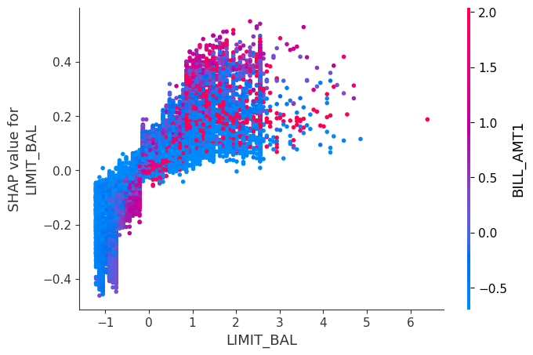

```python
shap.dependence_plot("LIMIT_BAL", lgbm_shap_values[0], X_train_enc)
```

As `LIMIT_BAL` increases, SHAP values for class 0 increase as well, suggesting that class is likely to be 0 (non default) with higher values for LIMIT_BAL, which makes sense.

```
No data for colormapping provided via 'c'. Parameters 'vmin', 'vmax' will be ignored
```

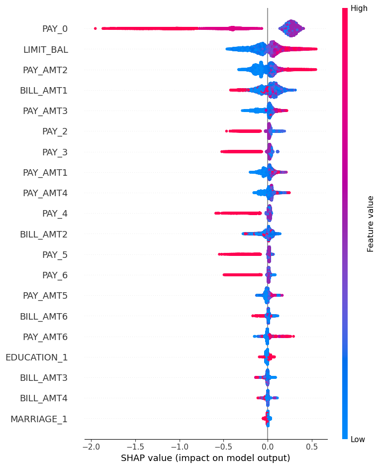

```python
shap.summary_plot(lgbm_shap_values[0], X_train_enc)
```

```python
X_test_enc = pd.DataFrame(
    data=preprocessor.transform(X_test),
    columns=feature_names,
    index=X_test.index,
)

test_lgbm_shap_values = lgbm_explainer.shap_values(X_test_enc)
```

```
LightGBM binary classifier with TreeExplainer shap values output has changed to a list of ndarray
```

```python
lgbm_tuned.predict_proba(X_test_enc)[1]
```

```
array([0.74058038, 0.25941962])
```

```python
lgbm_tuned.predict(X_test_enc, raw_score=True)[1]
```

```
-1.0489872894312522
```

```python
lgbm_explainer.expected_value
```

```
[0.5594117098974121, -0.5594117098974121]
```

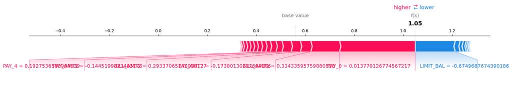

```python
shap.force_plot(
    lgbm_explainer.expected_value[0],
    test_lgbm_shap_values[0][1, :],
    X_test_enc.iloc[1, :],
    matplotlib=True,
)
```

**Summary of observations**

- From the analysis above we observe that **PAY_\d{0,2,3,4}**, **PAY_AMT**, **LIM_BAL** features seem to be one of the most important features with `PAY_0` being the topmost feature.
- The SHAP dependence plot demonstrates that the class is likely to be 0 (non default) for higher values for LIMIT_BAL, which makes sense.
- The features `EDUCATION` and `SEX` doesn't seem to influence the prediction much. This might be because of the noise in the `EDUCTION` column; there are a number of unknown values in this column.

## Results on the test set

```python
from sklearn.metrics import f1_score

best_model = random_search_lgbm.best_estimator_
print(
    "Grid Search best model validation score: %0.3f" % (random_search_lgbm.best_score_)
)

predictions = best_model.predict(X_test)
print(
    "Macro-average f1 score on the test set: %0.3f"
    % (f1_score(y_test, predictions, average="macro"))
)
```

```
Grid Search best model validation score: 0.708
Macro-average f1 score on the test set: 0.697
```

```
Function plot_confusion_matrix is deprecated; Function `plot_confusion_matrix` is deprecated in 1.0 and will be removed in 1.2. Use one of the class methods: ConfusionMatrixDisplay.from_predictions or ConfusionMatrixDisplay.from_estimator.
```

```
<sklearn.metrics._plot.confusion_matrix.ConfusionMatrixDisplay at 0x15225260850>
```

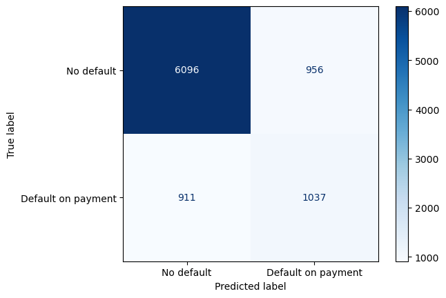

```python
from sklearn.metrics import classification_report, plot_confusion_matrix
import matplotlib.pyplot as plt

plot_confusion_matrix(
    best_model,
    X_test,
    y_test,
    display_labels=["No default", "Default on payment"],
    values_format="d",
    cmap=plt.cm.Blues,
)
```

```python
print(
    classification_report(
        y_test, predictions, target_names=["No default", "Default on payment"]
    )
)
```

```
                    precision    recall  f1-score   support

        No default       0.87      0.86      0.87      7052
Default on payment       0.52      0.53      0.53      1948

          accuracy                           0.79      9000
         macro avg       0.70      0.70      0.70      9000
      weighted avg       0.79      0.79      0.79      9000
```

Let's explain a default and a non-default test prediction using SHAP force plot. Let's first get indices for default and non-default examples.

```python
y_test_reset = y_test.reset_index(drop=True)
non_default_ind = y_test_reset[y_test_reset == 0].index.tolist()
default_ind = y_test_reset[y_test_reset == 1].index.tolist()

ex_non_default_index = non_default_ind[0]
ex_default_index = default_ind[0]
```

**Explanation of a non-default prediction**

```python
lgbm_tuned.predict_proba(X_test_enc)[ex_non_default_index]
```

```
array([0.697763, 0.302237])
```

```python
lgbm_tuned.predict(X_test_enc, raw_score=True)[ex_non_default_index]
```

```
-0.8366680315908269
```

```python
lgbm_explainer.expected_value
```

```
[0.5594117098974121, -0.5594117098974121]
```

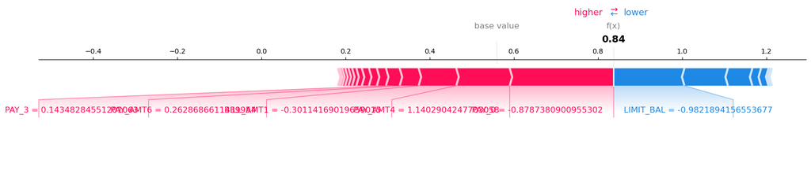

```python
shap.force_plot(
    lgbm_explainer.expected_value[0],
    test_lgbm_shap_values[0][ex_non_default_index, :],
    X_test_enc.iloc[ex_non_default_index, :],
    matplotlib=True,
)
```

- The raw model score is 0.84, which is greater than the base value 0.5594 and so the prediction is that the user is not likely to default on credit payment (because we are consider the shap values for class 0).

**Explanation of a default prediction**

```python
lgbm_tuned.predict_proba(X_test_enc)[ex_default_index]
```

```
array([0.26909715, 0.73090285])
```

```python
lgbm_tuned.predict(X_test_enc, raw_score=True)[ex_default_index]
```

```
0.9992080664830868
```

```python
lgbm_explainer.expected_value
```

```
[0.5594117098974121, -0.5594117098974121]
```

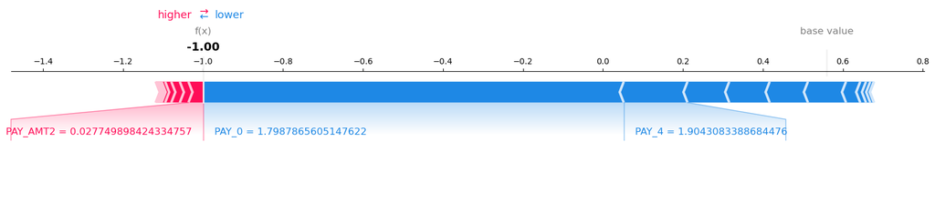

```python
shap.force_plot(
    lgbm_explainer.expected_value[0],
    test_lgbm_shap_values[0][ex_default_index, :],
    X_test_enc.iloc[ex_default_index, :],
    matplotlib=True,
)
```

- The raw model score is -1.00, which is smaller than the base value 0.5594 and so the prediction is that the user is likely to default on the credit payment (class 1).
- Positive values for PAY_* variables seem to push the prediction towards a lower value.